# Practical Machine Learning - Course Project

Brendan Madigan

Friday, May 15, 2015

## Overview

The data to be analysed relates to measurements taken from accelerometers placed on the belt, forearm, arm, and dumbell of 6 participants. These participants were asked to perform barbell lifts correctly and incorrectly in 5 different ways. The aim of this analysis is to predict the manner in which they performed each exercise.

## Data

The data is the Weight Lifting Exercise (WLE) Dataset. More information can be found on the website here: http://groupware.les.inf.puc-rio.br/har (see the section on the Weight Lifting Exercise Dataset).

More information may befound here:[Qualitative Activity Recognition of Weight Lifting Exercises](http://groupware.les.inf.puc-rio.br/work.jsf?p1=11201) - Proceedings of 4th International Conference in Cooperation with SIGCHI (Augmented Human ’13) . Stuttgart, Germany: ACM SIGCHI, 2013.

- Training data
- [Test data](https://d396qusza40orc.cloudfront.net/predmachlearn/pml-testing.csv)

Start by loading required libaries and setting any system variables. For information purposes display the start time of the analysis.

```
## PML Analysis started at: 2015-05-23 16:05:01
## R version: R version 3.2.0 (2015-04-16)
```

## Background

Using devices such as Jawbone Up, Nike FuelBand, and Fitbit it is now possible to collect a large amount of data about personal activity relatively inexpensively. These type of devices are part of the quantified self movement - a group of enthusiasts who take measurements about themselves regularly to improve their health, to find patterns in their behavior, or because they are tech geeks. One thing that people regularly do is quantify how much of a particular activity they do, but they rarely quantify how well they do it. In this project, your goal will be to use data from accelerometers on the belt, forearm, arm, and dumbell of 6 participants. They were asked to perform barbell lifts correctly and incorrectly in 5 different ways. More information is available from the website [here:](http://groupware.les.inf.puc-rio.br/har) (see the section on the Weight Lifting Exercise Dataset).

## Load the training and test data csv files.

```r
TrainDataURL  <- "https://d396qusza40orc.cloudfront.net/predmachlearn/pml-training.csv"
TestDataURL   <- "https://d396qusza40orc.cloudfront.net/predmachlearn/pml-testing.csv"
TrainingData  <- fread(TrainDataURL)
TestingData   <- fread(TestDataURL)
```

## Basic Data Analysis

- Display the number of observations in the TrainingData by user_name
- Produce a basic histogram of the TrainingData on classe and user names

```r
table(TrainingData$user_name)
```

```
##
##   adelmo carlitos  charles   eurico   jeremy    pedro
##     3892     3112     3536     3070     3402     2610
```

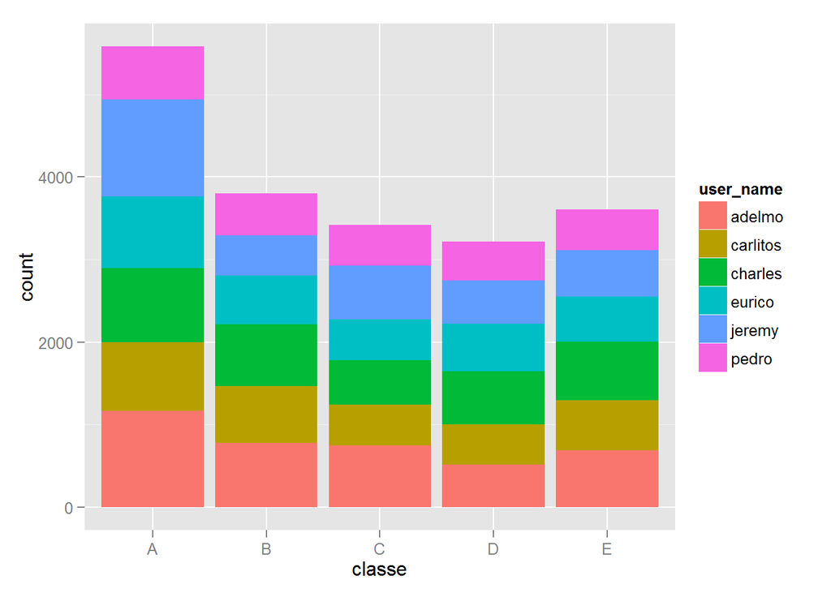

```r
qplot(classe, data=TrainingData, fill=user_name)
```

## Clean the data

Determine Which attributes in the testing data that don’t have missing data.

These attributes will then will be used in prediction modelling.

```r
MissingData <- sapply(TestingData, function (x) any(is.na(x) | x == ""))
PredictionAttributes  <- !MissingData & grepl("belt|arm|dumbbell", names(MissingData))

PredictionAttributes  <- names(MissingData)[PredictionAttributes]
PredictionAttributes
```

```
##  [1] "roll_belt"            "pitch_belt"           "yaw_belt"
##  [4] "total_accel_belt"     "gyros_belt_x"         "gyros_belt_y"
##  [7] "gyros_belt_z"         "accel_belt_x"         "accel_belt_y"
## [10] "accel_belt_z"         "magnet_belt_x"        "magnet_belt_y"
## [13] "magnet_belt_z"        "roll_arm"             "pitch_arm"
## [16] "yaw_arm"              "total_accel_arm"      "gyros_arm_x"
## [19] "gyros_arm_y"          "gyros_arm_z"          "accel_arm_x"
## [22] "accel_arm_y"          "accel_arm_z"          "magnet_arm_x"
## [25] "magnet_arm_y"         "magnet_arm_z"         "roll_dumbbell"
## [28] "pitch_dumbbell"       "yaw_dumbbell"         "total_accel_dumbbell"
## [31] "gyros_dumbbell_x"     "gyros_dumbbell_y"     "gyros_dumbbell_z"
## [34] "accel_dumbbell_x"     "accel_dumbbell_y"     "accel_dumbbell_z"
## [37] "magnet_dumbbell_x"    "magnet_dumbbell_y"    "magnet_dumbbell_z"
## [40] "roll_forearm"         "pitch_forearm"        "yaw_forearm"
## [43] "total_accel_forearm"  "gyros_forearm_x"      "gyros_forearm_y"
## [46] "gyros_forearm_z"      "accel_forearm_x"      "accel_forearm_y"
## [49] "accel_forearm_z"      "magnet_forearm_x"     "magnet_forearm_y"
## [52] "magnet_forearm_z"
```

```r
AttributesToInclude   <- c("classe", PredictionAttributes)
TrainingData          <- TrainingData[, AttributesToInclude, with=FALSE]

TrainingData          <- TrainingData[, classe := factor(TrainingData[, classe])]
TrainingData[, .N, classe]
```

```
##    classe    N
## 1:      A 5580
## 2:      B 3797
## 3:      C 3422
## 4:      D 3216
## 5:      E 3607
```

```r
PartitionTrainingData <-   createDataPartition(TrainingData$classe, p=0.6)
DataTraining          <-   TrainingData[ inTrain[[1]]]
DataTesting           <-   TrainingData[-inTrain[[1]]]
```

## Centre and scale the data.

```r
X                   <- DataTraining[, PredictionAttributes, with=FALSE]
preProc             <- preProcess(X)
preProc
```

```
##
## Call:
## preProcess.default(x = X)
##
## Created from 11776 samples and 52 variables
## Pre-processing: centered, scaled
```

```r
CentreAndScale      <- predict(preProc, X)
DataTrainingCS      <- data.table(data.frame(classe = DataTraining[, classe], CentreAndScale))

dim(DataTrainingCS)
```

```
## [1] 11776    53
```

```r
CentreAndScale      <- predict(preProc, DataTesting[, PredictionAttributes, with=FALSE])
DataTestingCS       <- data.table(data.frame(classe = DataTesting[, classe], CentreAndScale))

dim(DataTestingCS)
```

```
## [1] 7846   53
```

## Train the prediction model

- Set up parameters to allow parallel processing
- Set the control parameters
- Use the Random Forest algoriyhm
- Fit model over the tuning parameters

```r
ctrl          <- trainControl(classProbs     =TRUE,
                              savePredictions=TRUE,
                              allowParallel  =TRUE)
registerDoParallel()
trainingModel <- train(classe ~ ., data=DataTrainingCS, method="rf")
trainingModel
```

```
## Random Forest
##
## 11776 samples
##    52 predictor
##     5 classes: 'A', 'B', 'C', 'D', 'E'
##
## No pre-processing
## Resampling: Bootstrapped (25 reps)
##
## Summary of sample sizes: 11776, 11776, 11776, 11776, 11776, 11776, ...
##
## Resampling results across tuning parameters:
##
##   mtry  Accuracy   Kappa      Accuracy SD  Kappa SD
##    2    0.9857540  0.9819772  0.002609700  0.003291596
##   27    0.9875258  0.9842180  0.001799998  0.002276832
##   52    0.9815495  0.9766589  0.003393181  0.004290786
##
## Accuracy was used to select the optimal model using  the largest value.
## The final value used for the model was mtry = 27.
```

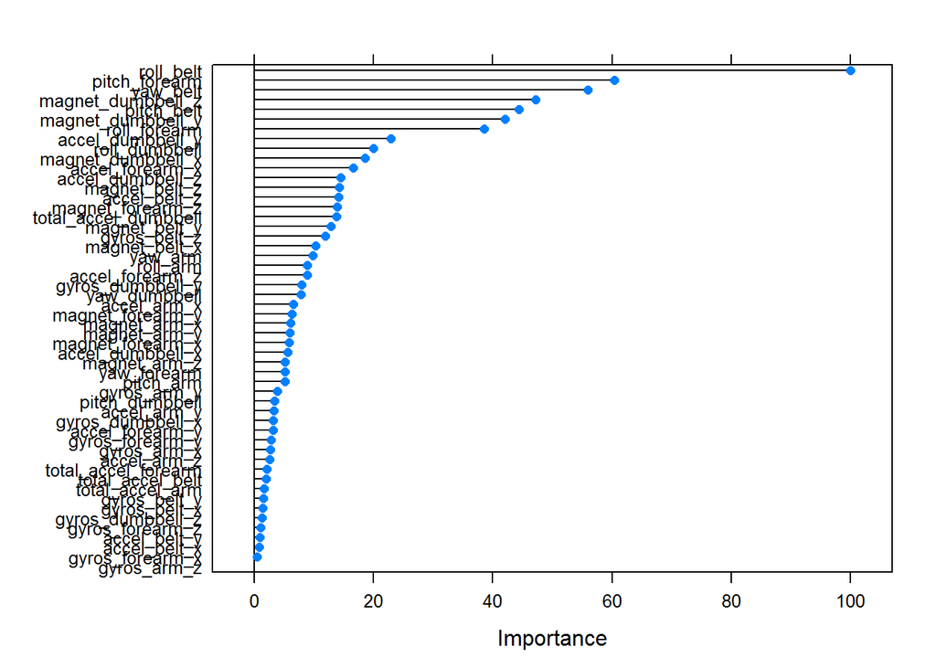

```r
plot(varImp(trainingModel))
```

```r
pred          <- predict(trainingModel, newdata=DataTestingCS)
sum(pred == DataTestingCS$classe) / length(pred)
```

```
## [1] 0.9912057
```

## Use the prediction model on the training data

```r
trainingModel
```

```
## Random Forest
##
## 11776 samples
##    52 predictor
##     5 classes: 'A', 'B', 'C', 'D', 'E'
##
## No pre-processing
## Resampling: Bootstrapped (25 reps)
##
## Summary of sample sizes: 11776, 11776, 11776, 11776, 11776, 11776, ...
##
## Resampling results across tuning parameters:
##
##   mtry  Accuracy   Kappa      Accuracy SD  Kappa SD
##    2    0.9857540  0.9819772  0.002609700  0.003291596
##   27    0.9875258  0.9842180  0.001799998  0.002276832
##   52    0.9815495  0.9766589  0.003393181  0.004290786
##
## Accuracy was used to select the optimal model using  the largest value.
## The final value used for the model was mtry = 27.
```

```r
PredictionResults <- predict(trainingModel, DataTrainingCS)
confusionMatrix(PredictionResults, DataTraining[, classe])
```

```
## Confusion Matrix and Statistics
##
##           Reference
## Prediction    A    B    C    D    E
##          A 3348    0    0    0    0
##          B    0 2279    0    0    0
##          C    0    0 2054    0    0
##          D    0    0    0 1930    0
##          E    0    0    0    0 2165
##
## Overall Statistics
##
##                Accuracy : 1
##                  95% CI : (0.9997, 1)
##     No Information Rate : 0.2843
##     P-Value [Acc > NIR] : < 2.2e-16
##
##                   Kappa : 1
##  Mcnemar's Test P-Value : NA
##
## Statistics by Class:
##
##                      Class: A Class: B Class: C Class: D Class: E
## Sensitivity            1.0000   1.0000   1.0000   1.0000   1.0000
## Specificity            1.0000   1.0000   1.0000   1.0000   1.0000
## Pos Pred Value         1.0000   1.0000   1.0000   1.0000   1.0000
## Neg Pred Value         1.0000   1.0000   1.0000   1.0000   1.0000
## Prevalence             0.2843   0.1935   0.1744   0.1639   0.1838
## Detection Rate         0.2843   0.1935   0.1744   0.1639   0.1838
## Detection Prevalence   0.2843   0.1935   0.1744   0.1639   0.1838
## Balanced Accuracy      1.0000   1.0000   1.0000   1.0000   1.0000
```

## Use the prediction model on the testing data

```r
PredictionResults <- predict(trainingModel, DataTestingCS)
confusionMatrix(PredictionResults, DataTestingCS[, classe])
```

```
## Confusion Matrix and Statistics
##
##           Reference
## Prediction    A    B    C    D    E
##          A 2226   11    0    0    0
##          B    5 1504   20    0    1
##          C    0    3 1344   15    5
##          D    0    0    4 1269    2
##          E    1    0    0    2 1434
##
## Overall Statistics
##
##                Accuracy : 0.9912
##                  95% CI : (0.9889, 0.9932)
##     No Information Rate : 0.2845
##     P-Value [Acc > NIR] : < 2.2e-16
##
##                   Kappa : 0.9889
##  Mcnemar's Test P-Value : NA
##
## Statistics by Class:
##
##                      Class: A Class: B Class: C Class: D Class: E
## Sensitivity            0.9973   0.9908   0.9825   0.9868   0.9945
## Specificity            0.9980   0.9959   0.9964   0.9991   0.9995
## Pos Pred Value         0.9951   0.9830   0.9832   0.9953   0.9979
## Neg Pred Value         0.9989   0.9978   0.9963   0.9974   0.9988
## Prevalence             0.2845   0.1935   0.1744   0.1639   0.1838
## Detection Rate         0.2837   0.1917   0.1713   0.1617   0.1828
## Detection Prevalence   0.2851   0.1950   0.1742   0.1625   0.1832
## Balanced Accuracy      0.9977   0.9933   0.9895   0.9929   0.9970
```

## Display the results of final model

```r
varImp(trainingModel)
```

```
## rf variable importance
##
##   only 20 most important variables shown (out of 52)
##
##                      Overall
## roll_belt            100.000
## pitch_forearm         60.440
## yaw_belt              55.999
## magnet_dumbbell_z     47.140
## pitch_belt            44.351
## magnet_dumbbell_y     42.090
## roll_forearm          38.529
## accel_dumbbell_y      22.868
## roll_dumbbell         19.940
## magnet_dumbbell_x     18.617
## accel_forearm_x       16.556
## accel_dumbbell_z      14.546
## magnet_belt_z         14.316
## accel_belt_z          14.199
## magnet_forearm_z      13.885
## total_accel_dumbbell  13.821
## magnet_belt_y         12.866
## gyros_belt_z          11.907
## magnet_belt_x         10.286
## yaw_arm                9.787
```

```r
trainingModel$finalModel
```

```
##
## Call:
##  randomForest(x = x, y = y, mtry = param$mtry)
##                Type of random forest: classification
##                      Number of trees: 500
## No. of variables tried at each split: 27
##
##         OOB estimate of  error rate: 0.79%
## Confusion matrix:
##      A    B    C    D    E  class.error
## A 3347    0    0    1    0 0.0002986858
## B   24 2249    6    0    0 0.0131636683
## C    0   17 2028    9    0 0.0126582278
## D    0    1   23 1905    1 0.0129533679
## E    0    1    2    8 2154 0.0050808314
```

## The estimated error rate is less than 1%.

```r
DataTestingCS       <- predict(preProc, TestingData[, PredictionAttributes, with=FALSE])
PredictionResults   <- predict(trainingModel, DataTestingCS)
TestingData         <- cbind(PredictionResults , TestingData)

subset(TestingData, select=names(TestingData)[grep("belt|[^(fore)]arm|dumbbell|forearm", names(TestingData), invert=TRUE)])
```

```
##     PredictionResults V1 user_name raw_timestamp_part_1
##  1:                 B  1     pedro           1323095002
##  2:                 A  2    jeremy           1322673067
##  3:                 B  3    jeremy           1322673075
##  4:                 A  4    adelmo           1322832789
##  5:                 A  5    eurico           1322489635
##  6:                 E  6    jeremy           1322673149
##  7:                 D  7    jeremy           1322673128
##  8:                 B  8    jeremy           1322673076
##  9:                 A  9  carlitos           1323084240
## 10:                 A 10   charles           1322837822
## 11:                 B 11  carlitos           1323084277
## 12:                 C 12    jeremy           1322673101
## 13:                 B 13    eurico           1322489661
## 14:                 A 14    jeremy           1322673043
```

[output cut: 27 more lines]

## Create the files to be submitted

Write submission files to `C:\Users\Brendan\DataScienceCourse\Machine Learning`.

```r
pml_write_files = function(x){
  n = length(x)
  path <- "C:/Users/Brendan/DataScienceCourse/Machine Learning"
  for(i in 1:n){
    filename = paste0("problem_id_",i,".txt")
    write.table(x[i],file=file.path(path, filename),quote=FALSE,row.name=FALSE,col.names=FALSE)
  }
}
pml_write_files(PredictionResults)
```

## Display the end time of the execution

```
## PML Analysis ended at : 2015-05-23 17:29:20
## R version: R version 3.2.0 (2015-04-16)
```

[output not shown]